# Mi proyecto Datos puntuales y Geoestadistica Proyecto final de Analisis Espacial Profesor :Jose Ramon Martinez Batlle

Maria Magdalena Viloria y Adalberto Guerrero

Estudiante, Universidad Autónoma de Santo Domingo (UASD)

December 12, 2019

Abstract

se presenta un conjunto de procesos y datos de precipitación, para ser usados en el paquete de R donde este permitirá su manipulación a través de sus distintas funcionalidades para obtener Datos puntuales y Geoestadistica para el año 1998 de las precipitaciones

# Introducción

Hemos tomado la precipitaciones del año 1998 para realizar una series de analisis geoestadistico donde cargaremos los datos de precipitaciones de la ONAMET en los cuales obtuvimos valores en los lugares no muestrados, se realizo prediciones basado en un año 1998, utilizando los elementos del variograma, el efecto pepita ademas generamos el variograma muestral, obtubimos el efecto proximo mediante el metodo Kriging ordinario, se detecto la autocorrelación espacial, es decir, relación entre observaciones debido a la estructrura espacial determinamos Si existe autocorrelación para que ésta pueda modelizarse adecuadamente, mediante un variograma modelo obtuvimos los datos estadisticos y la distribución que estos siguen.

las técnicas discutidas en este trabajo son realizada mediante los paquetes estadísticos de R ya que cuenta con una enorme variedad de pruebas estadísticas y representaciones graficas.

# Datos puntuales, geoestadística.

## Geoestadística

La Geoestadística es la rama de la estadística que se encarga del análisis de fenómenos espaciales que exhiben un comportamiento estructural, en este caso se centrado en el análisis de la variable precipitación a partir de cuatro métodos de interpolación que permitan obtener una delimitación más acorde del área de estudio ### Definición

La geoestadística se ocupa en modelar, predecir y simular fenómenos espacialmente continuos. En realidad, lo que aborda es la obtención de valores en lugares no muestreados. Dado que es imposible tomar muestras en todas partes, la geoestadística asiste en la predicción espacialmente continua del valor de una variable.

### Kriging

Considera un fenómeno *Z(s)*, muestreado en *s<sub>i</sub>*, con *i=1,2,3,…,n*, pero nos interesa su valor en todas las localidades, *s<sub>0</sub>*; debemos predecir *s<sub>0</sub>*, lo cual realizaremos de manera habitual con el método del krigeaje (krigeado o **kriging**), que consiste en una predicción Gaussiana.

Existen varias modalidades de krigeaje según los distintos supuestos (todas asumen que la variación espacial es modelizable mediante el variograma), siendo las más comunes las siguientes:

- **Kriging ordinario**. Asume **media constante y desconocida** en el entorno próximo de la observación *s<sub>i</sub>*. **No se asume que la media local tenga el mismo valor que la media poblacional**, es decir, no hay requisito de estacionariedad de primer momento. Dada las pocas asunciones que requiere en su implementación, y por su aproximación más conservadora, es muy empleado en varias disciplinas.
- **Kriging simple**. **Asume estacionariedad de primer momento** (media constante) en el dominio analizado, pero la media poblacional es conocida.
- **Kriging universal**. Asume una **tendencia general modelizada por polinomio**, como por ejemplo, un modelo lineal.

### Semivarianza y variograma

El kriging utiliza un modelo para ponderar las observaciones cercanas a *s<sub>0</sub>* denominado variograma o semivariograma. El variograma es el gráfico de representación de estimaciones de la semivarianza γ; esta última mide el grado de dependencia espacial entre muestras. En la medida en que aumenta la distancia entre pares de observaciones, se asume que la semivarianza aumenta igualmente. Observaciones cercanas obtendrán semivarianzas pequeñas, puesto que si existe autocorrelación espacial, observaciones cercanas serán muy parecidas.

En realidad, los programas de computo de la semivarianza utilizan un diseño geométrico de búsqueda basado en *lags* que se fijan de incrementalmente de acuerdo al tamaño de intervalo. Aunque la anchura de búsqueda es fija, los *lags* pueden ser múltiples, lo que complica significativamente los cálculos.

## Paquetes

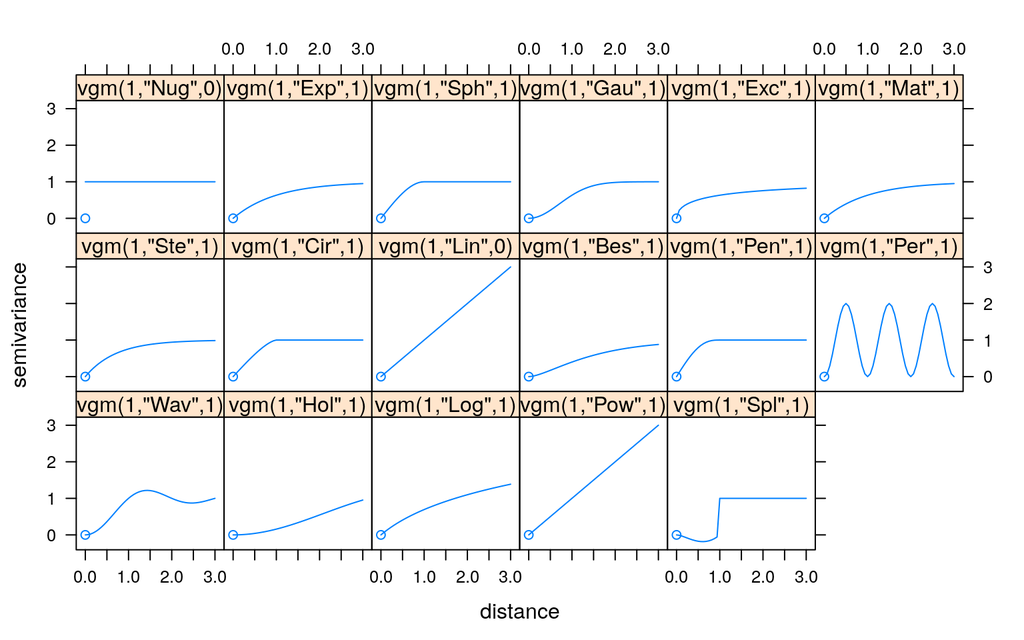

```r
library(gstat)
show.vgms()
```

```r
vgm()
```

| short | long |
| --- | --- |
| Nug | Nug (nugget) |
| Exp | Exp (exponential) |
| Sph | Sph (spherical) |
| Gau | Gau (gaussian) |
| Exc | Exclass (Exponential class/stable) |
| Mat | Mat (Matern) |
| Ste | Mat (Matern, M. Stein's parameterization) |
| Cir | Cir (circular) |
| Lin | Lin (linear) |
| Bes | Bes (bessel) |

[output cut: 10 more lines]

- Efecto “pepita” (*nugget*): corresponde a la variabilidad aleatoria inherente [variabilidad inframuestra, imposible de detectarse con la espaciación elegida en el diseño muestral].
- Rango (*range*), rango de influencia, alcance: corresponde a la distancia a la cual las muestras se tornan independientes, es la distancia donde se alcanza la meseta.
- Meseta (*psill*): correspondiente a la varianza estructural.

### ¿Cómo interpretar un variograma?

La principal tarea al generar un variograma consiste en detectar autocorrelación espacial, es decir, relación entre observaciones debido a la estructrura espacial. Si existe autocorrelación, ésta podrá modelizarse adecuadamente mediante un variograma modelo.

El variograma de una variable autocorrelacionada espacialmente muestra un incremento gradual de la semivarianza hasta que se alcanza la meseta en el rango (concretamente, al alcanzar el 95% de la semivarianza total). Esto implica que la semivarianza inicia en cero o cercana a éste para el intervalo de distancia cero.

En el caso de una variable no autocorrelacionada, ya sea porque tiene un comportamiento aleatorio o porque la distribución espacial de las observaciones es demasiado gruesa como para detectar la autocorrelación de escalas más detalladas (variabilidad inframuestra), en la distancia cero el variograma intercepta el eje de la semivarianza en valores significativamente elevados.

## Estudio de caso: precipitación de República Dominicana mediante kriging ordinario

En esta introducción realizaremos un **kriging ordinario** y un **kriging universal** utilizando los observatorios de precipitación de República Dominicana colectados por ONAMET.

### Datos fuente

Tomaremos como ejemplo la precipitación del año 1998. Primero carguemos los observatorios y las provincias:

```r
library(sf)
rutapre <- 'material-de-apoyo-master/data/onamet_prec_anual_sf.gpkg'
rutadiv <- 'material-de-apoyo-master/data/divisionRD.gpkg'
st_layers(rutapre)
```

```
## Driver: GPKG
## Available layers:
##             layer_name geometry_type features fields
## 1 onamet_prec_anual_sf         Point       25     37
```

```r
pre <- st_read(rutapre)
pre
```

| Estación | a1979 | a1980 | a1981 | a1982 | a1983 | a1984 | a1985 | a1986 | a1987 | a1988 | a1989 | a1990 | a1991 | a1992 | a1993 | a1994 | a1995 | a1996 | a1997 | a1998 | a1999 | a2000 | a2001 | a2002 | a2003 | a2004 | a2005 | a2006 | a2007 | … |
| --- | --- | --- | --- | --- | --- | --- | --- | --- | --- | --- | --- | --- | --- | --- | --- | --- | --- | --- | --- | --- | --- | --- | --- | --- | --- | --- | --- | --- | --- | --- |
| Barahona | 1740.0 | 1053.6 | 1435.3 | 815.30 | 1183.00 | 584.1 | 997.80 | 1080.00 | 1423.90 | 704.7 | 1011.600 | 1075.20 | 983.1 | 1112.500 | 968.5 | 1622.40 | 956.00 | 965.65 | 662.60 | 684.60 | 662.70 | 600.0 | 600.00 | 997.6 | 942.60 | 972.60 | 1274.600 | 1118.40 | 1531.30 | … |
| Bayaguana | 2794.3 | 1761.5 | 2412.4 | 1758.60 | 1857.10 | 1645.6 | 1928.30 | 2182.20 | 2273.50 | 1813.2 | 1730.600 | 1823.40 | 1850.3 | 1765.700 | 1606.2 | 1892.80 | 1360.10 | 1867.70 | 1618.60 | 2156.60 | 1712.50 | 1868.5 | 1796.10 | 1658.0 | 2117.30 | 1554.20 | 2102.800 | 2097.10 | 2137.60 | … |
| Cabrera | 2035.0 | 1276.8 | NA | 2136.90 | 1703.80 | 1888.7 | 1557.10 | 1597.00 | 2059.70 | NA | 1176.900 | 1183.40 | 957.6 | NA | NA | NA | NA | NA | NA | NA | NA | 1538.6 | 1852.90 | 946.9 | 1810.95 | 2053.30 | 1451.100 | 1957.90 | NA | … |
| Constanza | 1652.1 | 1166.9 | 1343.3 | 921.20 | 828.40 | NA | 892.80 | 715.80 | 786.90 | 837.7 | 671.500 | 875.35 | NA | 858.600 | 858.6 | 900.70 | 839.40 | 1167.30 | 525.10 | 1492.70 | 1077.80 | 951.3 | 787.10 | 959.2 | 1084.10 | 985.90 | 1245.200 | 1162.20 | 1661.40 | … |
| Gaspar Hernández | NA | 1443.8 | 2174.9 | 1844.10 | 1688.80 | 2208.8 | 1895.50 | 2874.70 | 2360.80 | 1426.3 | 1214.200 | 1530.70 | NA | 1257.500 | 1345.3 | 1824.90 | 1665.45 | 2656.80 | 984.80 | 2147.90 | 1791.90 | 1716.9 | 2178.80 | 1093.4 | 2058.50 | 1906.80 | 2001.850 | 1992.00 | 3282.65 | … |
| Hondo Valle | 1823.6 | 1778.2 | 2203.7 | 1709.90 | 1841.30 | 1796.6 | 1309.50 | 1589.70 | 1778.80 | 1766.5 | 1722.800 | 1596.10 | 1088.4 | 1731.000 | 1887.0 | 1772.00 | 1288.30 | 1447.90 | 912.65 | 1813.90 | 1762.20 | 2285.9 | 1604.30 | 1477.4 | 1628.10 | 1617.70 | 1554.650 | 1487.15 | 1487.15 | … |
| Jimaní | 1060.7 | 639.1 | 960.2 | 507.50 | 610.70 | 641.5 | 689.60 | 802.40 | 648.90 | 521.0 | 680.700 | 880.00 | 311.6 | 809.200 | 472.9 | 840.20 | 909.00 | 816.20 | 358.20 | 824.10 | 1037.00 | 833.9 | 488.40 | 510.1 | 656.70 | 866.90 | 929.300 | 963.90 | 1084.00 | … |
| La Unión | 1781.5 | 1630.6 | 2304.4 | 1413.10 | 1288.40 | 1499.4 | 1157.10 | 1313.10 | 1786.50 | 1888.8 | 1222.800 | 1808.00 | 1250.4 | 1555.200 | 1484.8 | 1035.90 | 877.70 | 1980.50 | 554.20 | 1744.10 | 1314.30 | 1148.5 | 1360.50 | 972.1 | 1802.00 | 2550.10 | 2034.300 | 2106.60 | 2764.80 | … |
| La Vega | 1833.5 | 1304.3 | 1993.7 | 1483.20 | 1353.90 | 1550.1 | 1084.90 | 1767.10 | 1663.20 | 1934.9 | 1192.400 | 1664.40 | 1146.4 | 1565.600 | 1855.4 | 1455.70 | 1175.40 | 1772.50 | 1018.80 | 1549.60 | 1817.90 | 1368.6 | 1522.00 | 1200.7 | 2290.60 | 1825.70 | 1245.200 | 1162.20 | 1661.40 | … |
| Las Américas | 1958.4 | 958.7 | 1513.4 | 787.40 | 975.50 | 954.9 | 1398.20 | 1419.00 | 1866.40 | 1620.5 | 1151.700 | NA | 997.0 | NA | NA | NA | 1017.50 | 1019.60 | 651.20 | 1218.60 | 1125.90 | 809.7 | 747.60 | 933.4 | 1083.60 | 1338.90 | 1744.600 | 1141.70 | 1457.50 | … |

[output cut: 15 more lines]

```r
st_layers(rutadiv)
```

```
## Driver: GPKG
## Available layers:
##      layer_name geometry_type features fields
## 1 PROVCenso2010       Polygon       32      4
## 2  MUNCenso2010       Polygon      155      5
## 3  REGCenso2010       Polygon       10      2
```

```r
prov <- st_read(rutadiv, layer = 'PROVCenso2010')
prov
```

| PROV | REG | TOPONIMIA | ENLACE | geom |
| --- | --- | --- | --- | --- |
| 01 | 10 | DISTRITO NACIONAL | 1001 |  |
| 02 | 05 | AZUA | 0502 |  |
| 03 | 06 | BAORUCO | 0603 |  |
| 04 | 06 | BARAHONA | 0604 |  |
| 05 | 04 | DAJABÓN | 0405 |  |
| 06 | 03 | DUARTE | 0306 |  |
| 07 | 07 | ELÍAS PIÑA | 0707 |  |
| 08 | 08 | EL SEIBO | 0808 |  |
| 09 | 01 | ESPAILLAT | 0109 |  |
| 10 | 06 | INDEPENDENCIA | 0610 |  |

[output cut: 22 more lines]

Exploremos el CRS del objeto `obs`.

```r
st_crs(pre)
```

```
## Coordinate Reference System:
##   EPSG: 4326
##   proj4string: "+proj=longlat +datum=WGS84 +no_defs"
```

Transformemos a 32619:

```r
crsdestino <- 32619
preutm <- pre %>% st_transform(crs = crsdestino)
preutm
```

| Estación | a1979 | a1980 | a1981 | a1982 | a1983 | a1984 | a1985 | a1986 | a1987 | a1988 | a1989 | a1990 | a1991 | a1992 | a1993 | a1994 | a1995 | a1996 | a1997 | a1998 | a1999 | a2000 | a2001 | a2002 | a2003 | a2004 | a2005 | a2006 | a2007 | … |
| --- | --- | --- | --- | --- | --- | --- | --- | --- | --- | --- | --- | --- | --- | --- | --- | --- | --- | --- | --- | --- | --- | --- | --- | --- | --- | --- | --- | --- | --- | --- |
| Barahona | 1740.0 | 1053.6 | 1435.3 | 815.30 | 1183.00 | 584.1 | 997.80 | 1080.00 | 1423.90 | 704.7 | 1011.600 | 1075.20 | 983.1 | 1112.500 | 968.5 | 1622.40 | 956.00 | 965.65 | 662.60 | 684.60 | 662.70 | 600.0 | 600.00 | 997.6 | 942.60 | 972.60 | 1274.600 | 1118.40 | 1531.30 | … |
| Bayaguana | 2794.3 | 1761.5 | 2412.4 | 1758.60 | 1857.10 | 1645.6 | 1928.30 | 2182.20 | 2273.50 | 1813.2 | 1730.600 | 1823.40 | 1850.3 | 1765.700 | 1606.2 | 1892.80 | 1360.10 | 1867.70 | 1618.60 | 2156.60 | 1712.50 | 1868.5 | 1796.10 | 1658.0 | 2117.30 | 1554.20 | 2102.800 | 2097.10 | 2137.60 | … |
| Cabrera | 2035.0 | 1276.8 | NA | 2136.90 | 1703.80 | 1888.7 | 1557.10 | 1597.00 | 2059.70 | NA | 1176.900 | 1183.40 | 957.6 | NA | NA | NA | NA | NA | NA | NA | NA | 1538.6 | 1852.90 | 946.9 | 1810.95 | 2053.30 | 1451.100 | 1957.90 | NA | … |
| Constanza | 1652.1 | 1166.9 | 1343.3 | 921.20 | 828.40 | NA | 892.80 | 715.80 | 786.90 | 837.7 | 671.500 | 875.35 | NA | 858.600 | 858.6 | 900.70 | 839.40 | 1167.30 | 525.10 | 1492.70 | 1077.80 | 951.3 | 787.10 | 959.2 | 1084.10 | 985.90 | 1245.200 | 1162.20 | 1661.40 | … |
| Gaspar Hernández | NA | 1443.8 | 2174.9 | 1844.10 | 1688.80 | 2208.8 | 1895.50 | 2874.70 | 2360.80 | 1426.3 | 1214.200 | 1530.70 | NA | 1257.500 | 1345.3 | 1824.90 | 1665.45 | 2656.80 | 984.80 | 2147.90 | 1791.90 | 1716.9 | 2178.80 | 1093.4 | 2058.50 | 1906.80 | 2001.850 | 1992.00 | 3282.65 | … |
| Hondo Valle | 1823.6 | 1778.2 | 2203.7 | 1709.90 | 1841.30 | 1796.6 | 1309.50 | 1589.70 | 1778.80 | 1766.5 | 1722.800 | 1596.10 | 1088.4 | 1731.000 | 1887.0 | 1772.00 | 1288.30 | 1447.90 | 912.65 | 1813.90 | 1762.20 | 2285.9 | 1604.30 | 1477.4 | 1628.10 | 1617.70 | 1554.650 | 1487.15 | 1487.15 | … |
| Jimaní | 1060.7 | 639.1 | 960.2 | 507.50 | 610.70 | 641.5 | 689.60 | 802.40 | 648.90 | 521.0 | 680.700 | 880.00 | 311.6 | 809.200 | 472.9 | 840.20 | 909.00 | 816.20 | 358.20 | 824.10 | 1037.00 | 833.9 | 488.40 | 510.1 | 656.70 | 866.90 | 929.300 | 963.90 | 1084.00 | … |
| La Unión | 1781.5 | 1630.6 | 2304.4 | 1413.10 | 1288.40 | 1499.4 | 1157.10 | 1313.10 | 1786.50 | 1888.8 | 1222.800 | 1808.00 | 1250.4 | 1555.200 | 1484.8 | 1035.90 | 877.70 | 1980.50 | 554.20 | 1744.10 | 1314.30 | 1148.5 | 1360.50 | 972.1 | 1802.00 | 2550.10 | 2034.300 | 2106.60 | 2764.80 | … |
| La Vega | 1833.5 | 1304.3 | 1993.7 | 1483.20 | 1353.90 | 1550.1 | 1084.90 | 1767.10 | 1663.20 | 1934.9 | 1192.400 | 1664.40 | 1146.4 | 1565.600 | 1855.4 | 1455.70 | 1175.40 | 1772.50 | 1018.80 | 1549.60 | 1817.90 | 1368.6 | 1522.00 | 1200.7 | 2290.60 | 1825.70 | 1245.200 | 1162.20 | 1661.40 | … |
| Las Américas | 1958.4 | 958.7 | 1513.4 | 787.40 | 975.50 | 954.9 | 1398.20 | 1419.00 | 1866.40 | 1620.5 | 1151.700 | NA | 997.0 | NA | NA | NA | 1017.50 | 1019.60 | 651.20 | 1218.60 | 1125.90 | 809.7 | 747.60 | 933.4 | 1083.60 | 1338.90 | 1744.600 | 1141.70 | 1457.50 | … |

[output cut: 15 more lines]

### EDA básico

Obtengamos los estadísticos básicos para el año 1998:

```r
nrow(preutm)
```

```
## [1] 25
```

```r
summary(preutm$a1998)
```

```
##    Min. 1st Qu.  Median    Mean 3rd Qu.    Max.    NA's
##   684.6  1151.7  1580.5  1644.0  1987.7  3011.3       2
```

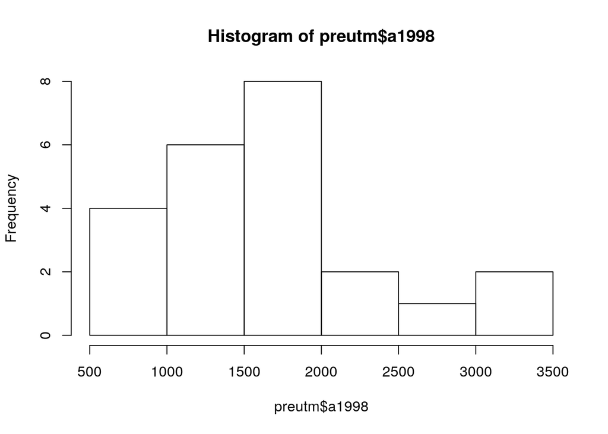

```r
hist(preutm$a1998)
```

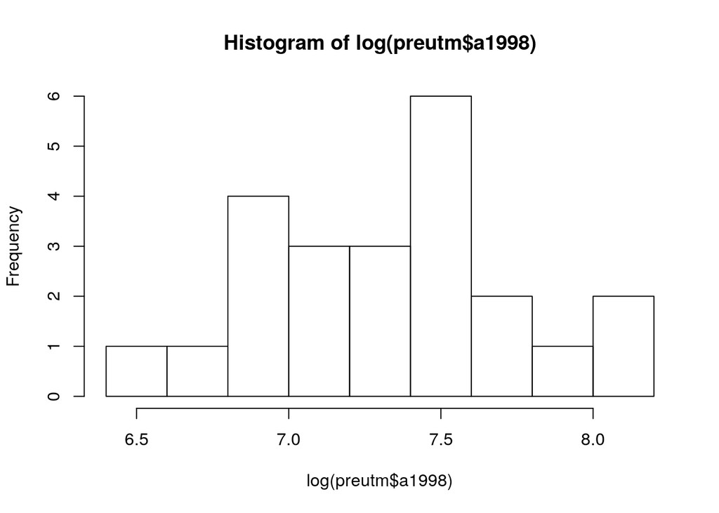

```r
hist(log(preutm$a1998))
```

```r
shapiro.test(preutm$a1998)
```

```
##
##  Shapiro-Wilk normality test
##
## data:  preutm$a1998
## W = 0.94806, p-value = 0.2666
```

```r
shapiro.test(log(pre$a1998))
```

```
##
##  Shapiro-Wilk normality test
##
## data:  log(pre$a1998)
## W = 0.97788, p-value = 0.8671
```

Como vemos, los datos siguen distribución normal, pero hay algo de sesgo hacia la derecha en la distribución. Igualmente, de los 25 observatorios que hay en todo el país, para 1998 en al menos 2 hay datos perdidos (`NA`). Eliminemos dichos observatorios, generemos un objeto que incluya solamente a 1998 y que contenga igualmente una columna con datos transformados:

```r
pre1998 <- na.omit(preutm[,c('Estación', 'a1998')])
pre1998$a1998log <- log(pre1998$a1998)
pre1998
```

|  | Estación | a1998 | geom | a1998log |
| --- | --- | --- | --- | --- |
| 1 | Barahona | 684.60 |  | 6.528835 |
| 2 | Bayaguana | 2156.60 |  | 7.676288 |
| 4 | Constanza | 1492.70 |  | 7.308342 |
| 5 | Gaspar Hernández | 2147.90 |  | 7.672246 |
| 6 | Hondo Valle | 1813.90 |  | 7.503235 |
| 7 | Jimaní | 824.10 |  | 6.714292 |
| 8 | La Unión | 1744.10 |  | 7.463994 |
| 9 | La Vega | 1549.60 |  | 7.345752 |
| 10 | Las Américas | 1218.60 |  | 7.105458 |
| 11 | Moca | 1036.40 |  | 6.943508 |

[output cut: 13 more lines]

Representemos los observatorios, estilizando por tono según la precipitación del año 1998:

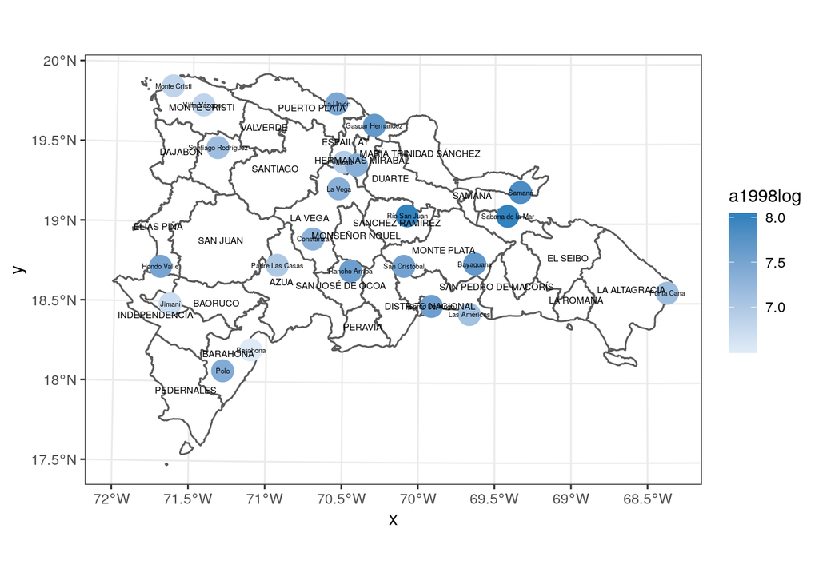

```r
library(ggplot2)
ggplot() +
  geom_sf(data = prov, fill = 'white') +
  geom_sf(data = pre1998, aes(col = a1998log), size = 6) +
  scale_colour_gradient(low="#deebf7", high="#3182bd") +
  geom_sf_text(data = prov, aes(label=TOPONIMIA), check_overlap = T, size = 2) +
  geom_sf_text(data = pre1998, aes(label=Estación), check_overlap = T, size = 1.5) +
  theme_bw()
```

### Variograma muestral

Generemos el variograma muestral para el logaritmo de la precipitación. Para ello empleamos la función `variogram`.

```r
v98 <- variogram(a1998log~1, pre1998)
v98
```

| np | dist | gamma | dir.hor | dir.ver | id |
| --- | --- | --- | --- | --- | --- |
| 1 | 8896.559 | 0.08905032 | 0 | 0 | var1 |
| 6 | 22368.506 | 0.13141962 | 0 | 0 | var1 |
| 10 | 32110.478 | 0.08693293 | 0 | 0 | var1 |
| 6 | 40706.420 | 0.03361319 | 0 | 0 | var1 |
| 6 | 50780.415 | 0.12041650 | 0 | 0 | var1 |
| 12 | 58446.995 | 0.10567299 | 0 | 0 | var1 |
| 8 | 67239.009 | 0.06443833 | 0 | 0 | var1 |
| 7 | 77115.401 | 0.11793609 | 0 | 0 | var1 |
| 17 | 85657.115 | 0.15764350 | 0 | 0 | var1 |
| 12 | 93304.363 | 0.11849679 | 0 | 0 | var1 |

[output cut: 4 more lines]

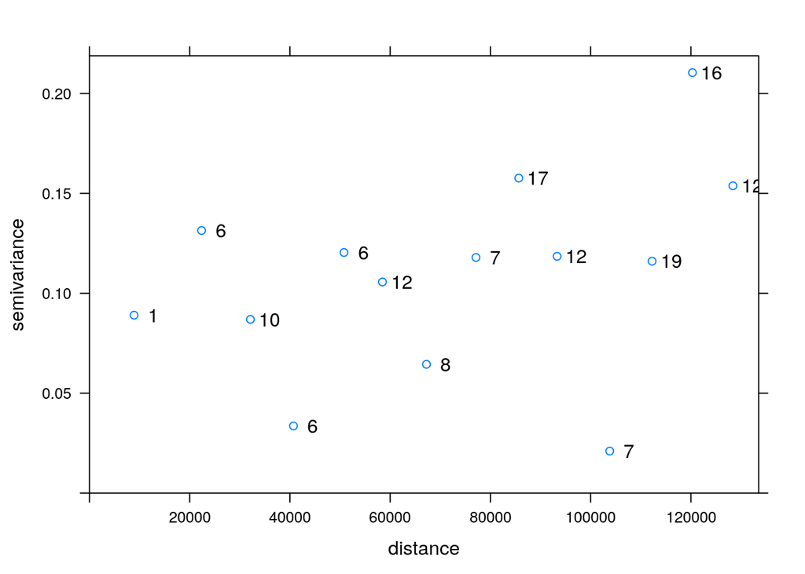

```r
plot(v98, plot.numbers = T)
```

Nótese la fórmula `a1998log~1`, la cual indica que la precipitación de 1998 es la variable sobre la cual se generará el variograma contra un modelo de media, que en este caso es simplemente un intercepto (media desconocida y constante). Típicamente, este variograma servirá para realizar un kriging ordinario.

La función `variogram` fija una distancia máxima de búsqueda (`cutoff`), que equivale a un tercio de la diagonal del recuadro delimitador (*bounding box*), y fija intervalos de anchura constante (`width`, que es la distancia de los intervalos *h<sub>i</sub>*, referida anteriormente) equivalentes a `cutoff/15`. Dichos parámetros, `cutoff` y `width` pueden modificarse por argumentos dentro de la función `variogram`.

### Variograma modelo

A partir del variograma muestral, generamos un variograma modelo que será el que utlizará la función `krige` para realizar la interpolación. Probamos varias opciones en función de lo visto en el variograma muestral.

```r
v98_m <- fit.variogram(v98, vgm(model = "Sph", range = 50000))
v98_m
```

| model | psill | range | kappa | ang1 | ang2 | ang3 | anis1 | anis2 |
| --- | --- | --- | --- | --- | --- | --- | --- | --- |
| Sph | 0.1078617 | 13982.71 | 0.5 | 0 | 0 | 0 | 1 | 1 |

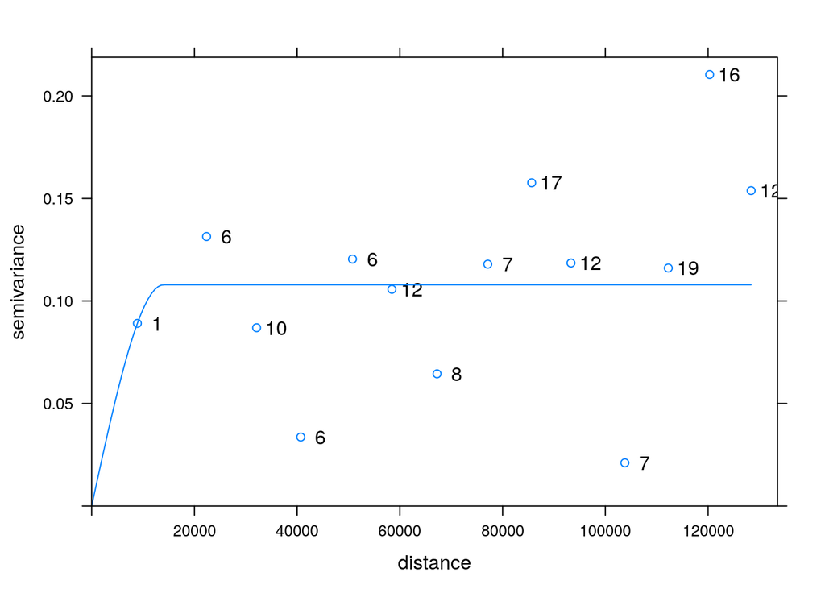

```r
plot(v98, v98_m, plot.numbers = T)
```

```r
v98_m2 <- fit.variogram(v98, vgm(model = "Exp", range = 50000))
v98_m2
```

| model | psill | range | kappa | ang1 | ang2 | ang3 | anis1 | anis2 |
| --- | --- | --- | --- | --- | --- | --- | --- | --- |
| Exp | 0.1073634 | 4605.641 | 0.5 | 0 | 0 | 0 | 1 | 1 |

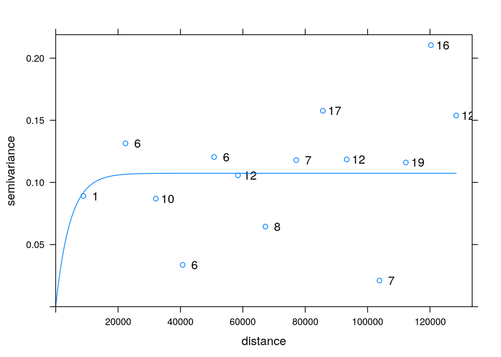

```r
plot(v98, v98_m2, plot.numbers = T)
```

```r
v98_m3 <- fit.variogram(v98, vgm(model = "Gau", range = 50000))
v98_m3
```

| model | psill | range | kappa | ang1 | ang2 | ang3 | anis1 | anis2 |
| --- | --- | --- | --- | --- | --- | --- | --- | --- |
| Gau | 0.1078316 | 5250.27 | 0.5 | 0 | 0 | 0 | 1 | 1 |

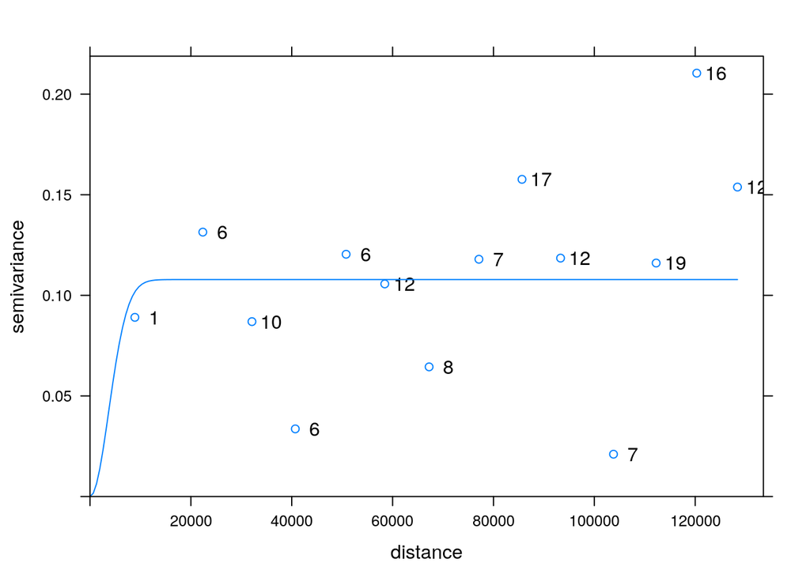

```r
plot(v98, v98_m3, plot.numbers = T)
```

```r
attr(v98_m, 'SSErr')
```

```
## [1] 5.877132e-11
```

```r
attr(v98_m2, 'SSErr') #Elegimos este
```

```
## [1] 5.93196e-11
```

```r
attr(v98_m3, 'SSErr')
```

```
## [1] 6.080129e-11
```

### Interpolación por kriging ordinario

Antes de realizar la interpolación, necesitamos una cuadrícula que “llenaremos” con las predicciones. Creemos una cuadrícula para RD, en este caso, de baja resolución, 10x10km:

```r
library(stars)
grd <- st_bbox(prov) %>%
  st_as_stars(dx = 10000) %>% #10000 metros=10km de resolución espacial
  st_set_crs(crsdestino) %>%
  st_crop(prov)
grd
```

```
## stars object with 2 dimensions and 1 attribute
## attribute(s):
##     values
##  Min.   :0
##  1st Qu.:0
##  Median :0
##  Mean   :0
##  3rd Qu.:0
##  Max.   :0
##  NA's   :605
## dimension(s):
##   from to  offset  delta                       refsys point values
## x    1 39  182216  10000 +proj=utm +zone=19 +datum...    NA   NULL [x]
## y    1 28 2205216 -10000 +proj=utm +zone=19 +datum...    NA   NULL [y]
```

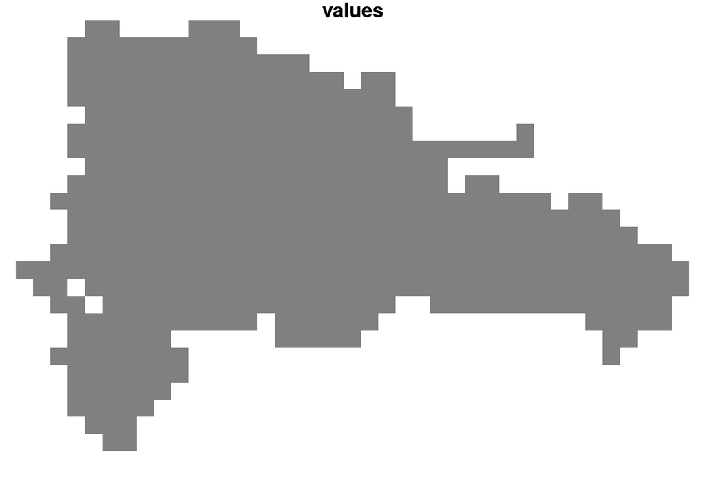

```r
plot(grd)
```

Sobre ella, ejecutamos la interpolación por kriging ordinario. La función `krige` asume que se trata de kriging ordinario, dado que no se especifica un valor para el argumento `beta`, o media.

```r
k <- krige(formula = a1998log~1, locations = pre1998, newdata = grd, model = v98_m2)
```

```
## [using ordinary kriging]
```

```r
k
```

```
## stars object with 2 dimensions and 2 attributes
## attribute(s):
##    var1.pred       var1.var
##  Min.   :6.951   Min.   :0.0542
##  1st Qu.:7.330   1st Qu.:0.1115
##  Median :7.331   Median :0.1120
##  Mean   :7.332   Mean   :0.1103
##  3rd Qu.:7.333   3rd Qu.:0.1121
##  Max.   :7.641   Max.   :0.1121
##  NA's   :605     NA's   :605
## dimension(s):
##   from to  offset  delta                       refsys point values
## x    1 39  182216  10000 +proj=utm +zone=19 +datum...    NA   NULL [x]
## y    1 28 2205216 -10000 +proj=utm +zone=19 +datum...    NA   NULL [y]
```

El objeto `k` es un ráster `stars` con dos variables, `var1.pred` y `var1.var`, que son, respectivamente, la predicción y la varianza de la predicción. La función `plot` contiene un método para imprimir el objeto `k`.

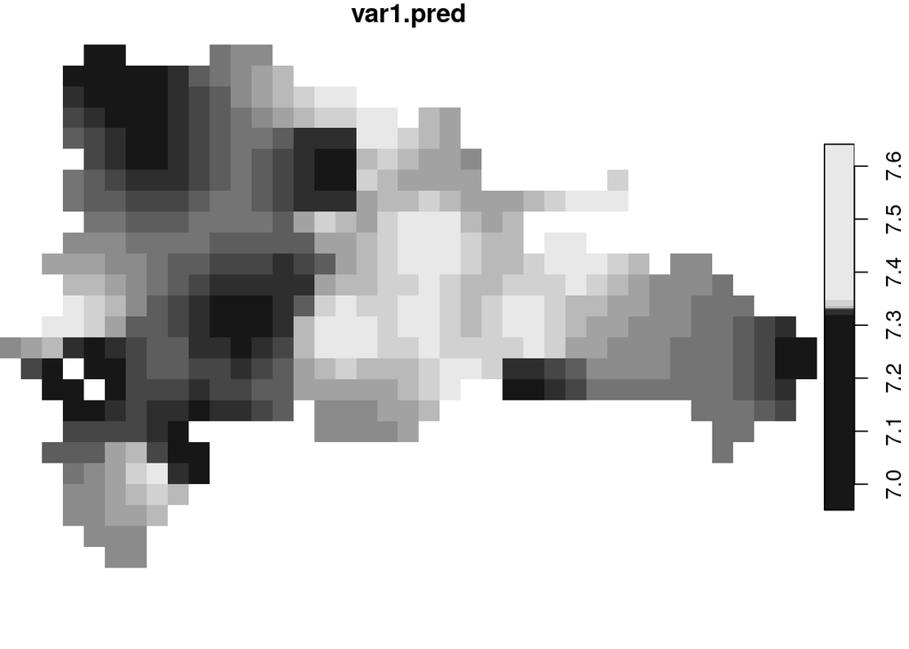

```r
plot(k)
```

Utilicemos `ggplot` para representar el objeto `stars`.

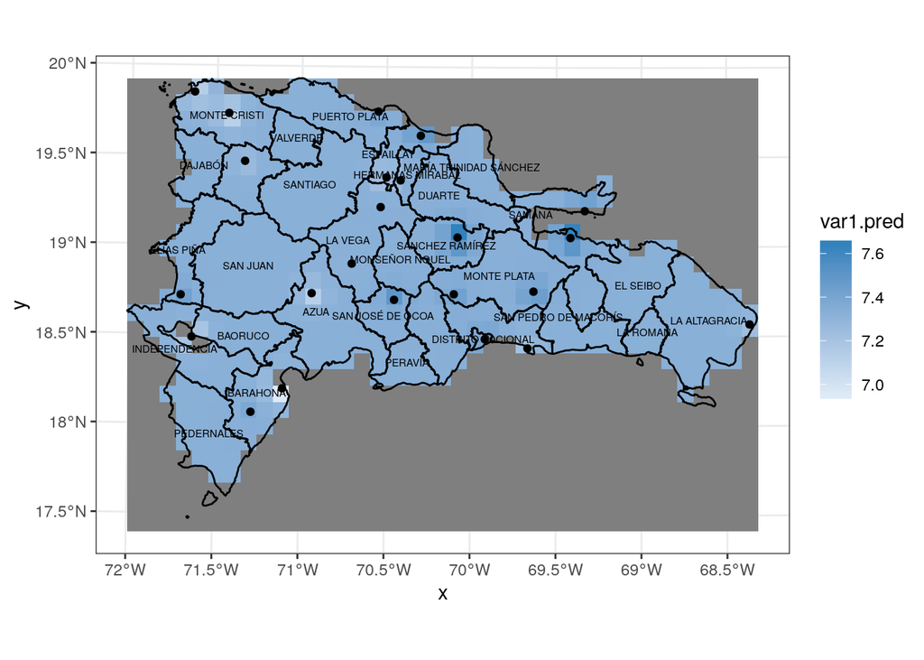

```r
ggplot() +
  geom_stars(data = k, aes(fill = var1.pred, x = x, y = y)) +
  scale_fill_gradient(low="#deebf7", high="#3182bd") +
  geom_sf(data = st_cast(prov, "MULTILINESTRING")) +
  geom_sf(data = pre1998) +
  geom_sf_text(data = prov, aes(label=TOPONIMIA), check_overlap = T, size = 2) +
  theme_bw()
```

Si queremos representar los valores de precipitación, debemos realizar la operación inversa, que sería elevar al `e` el valor predicho en `k`, lo cual se realiza mediante la función `exp()`.

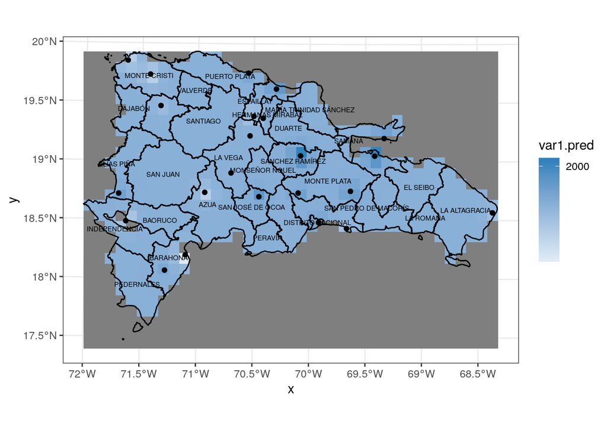

```r
ggplot() +
  geom_stars(data = exp(k), aes(fill = var1.pred, x = x, y = y)) +
  scale_fill_gradient(low="#deebf7", high="#3182bd", trans = 'log10') +
  geom_sf(data = st_cast(prov, "MULTILINESTRING")) +
  geom_sf(data = pre1998) +
  geom_sf_text(data = prov, aes(label=TOPONIMIA), check_overlap = T, size = 2) +
  theme_bw()
```

## Estudio de caso: temperatura de República Dominicana mediante kriging universal

El kriging universal predice el valor de la variable de interés en función del modelo espacial aportado por el variograma Y, al mismo tiempo, considerando covariables mediante polinomios. En este ejemplo, tomaremos la temperatura registrada en observatorios de ONAMET.

### Datos fuente

```r
rutatemp <- 'material-de-apoyo-master/data/onamet_temp_anual.gpkg'
st_layers(rutatemp)
```

```
## Driver: GPKG
## Available layers:
##          layer_name geometry_type features fields
## 1 onamet_temp_anual         Point       72     14
```

```r
temp <- st_read(rutatemp)
temp
```

| nombre | ene | feb | mar | abr | may | jun | jul | ago | sep | oct | nov | dic | tanual | geom |
| --- | --- | --- | --- | --- | --- | --- | --- | --- | --- | --- | --- | --- | --- | --- |
| HERRERA | 24.6 | 24.4 | 24.8 | 25.8 | 26.4 | 27.1 | 27.4 | 27.4 | 27.1 | 26.9 | 26.1 | 25.1 | 26.1 |  |
| LA UNION | 23.3 | 23.3 | 23.8 | 24.7 | 25.7 | 27.0 | 27.0 | 27.1 | 26.9 | 26.3 | 25.0 | 23.7 | 25.3 |  |
| ARROYO BARRIL | 24.6 | 24.9 | 25.6 | 26.1 | 26.4 | 27.1 | 27.1 | 26.8 | 26.8 | 26.6 | 25.7 | 25.0 | 26.1 |  |
| AZUA | 25.2 | 25.5 | 26.2 | 26.8 | 27.3 | 27.7 | 28.4 | 28.5 | 28.1 | 27.4 | 26.6 | 25.5 | 26.9 |  |
| BANI | 25.9 | 26.0 | 26.7 | 27.4 | 27.6 | 27.9 | 28.6 | 28.5 | 28.1 | 27.6 | 27.0 | 25.9 | 27.3 |  |
| BARAHONA | 24.6 | 24.8 | 25.4 | 26.2 | 26.7 | 27.3 | 27.9 | 27.9 | 27.5 | 26.7 | 26.2 | 25.2 | 26.4 |  |
| BAYAGUANA | 24.6 | 24.9 | 25.6 | 26.3 | 27.0 | 27.6 | 27.7 | 27.6 | 27.5 | 27.2 | 26.3 | 25.0 | 26.4 |  |
| BONAO | 23.4 | 23.8 | 24.6 | 25.4 | 25.9 | 26.8 | 26.9 | 27.0 | 26.8 | 26.4 | 25.2 | 23.8 | 25.5 |  |
| CABRERA | 24.7 | 24.8 | 25.2 | 25.6 | 26.0 | 26.6 | 26.8 | 26.8 | 26.7 | 26.5 | 25.7 | 24.9 | 25.9 |  |
| CEVICOS | 23.0 | 23.4 | 24.3 | 25.2 | 26.0 | 26.6 | 26.6 | 26.6 | 26.6 | 26.1 | 24.7 | 23.3 | 25.2 |  |

[output cut: 62 more lines]

Exploremos el CRS del objeto `obs`.

```r
st_crs(temp)
```

```
## Coordinate Reference System:
##   EPSG: 32619
##   proj4string: "+proj=utm +zone=19 +datum=WGS84 +units=m +no_defs"
```

Dado que es EPSG:32619 no necesitamos realizar transformación alguna.

### EDA básico

Obtengamos los estadísticos básicos del objeto `temp` y de su variable `tanual`:

```r
nrow(temp)
```

```
## [1] 72
```

```r
summary(temp$tanual)
```

```
##    Min. 1st Qu.  Median    Mean 3rd Qu.    Max.
##   18.20   25.20   25.90   25.50   26.43   28.40
```

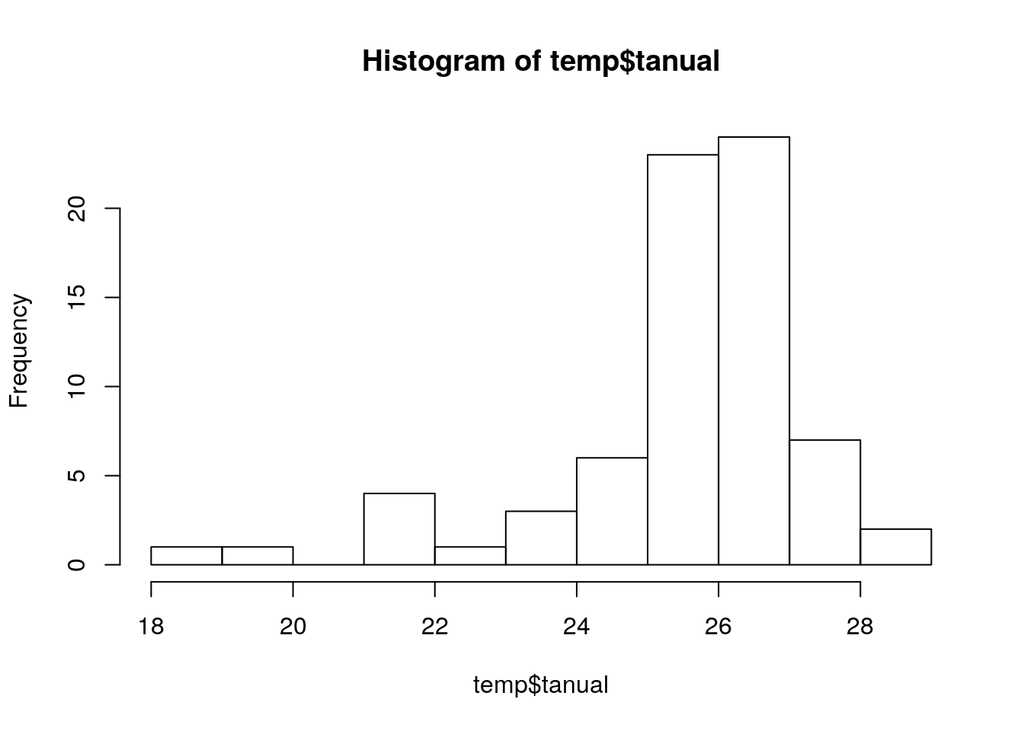

```r
hist(temp$tanual)
```

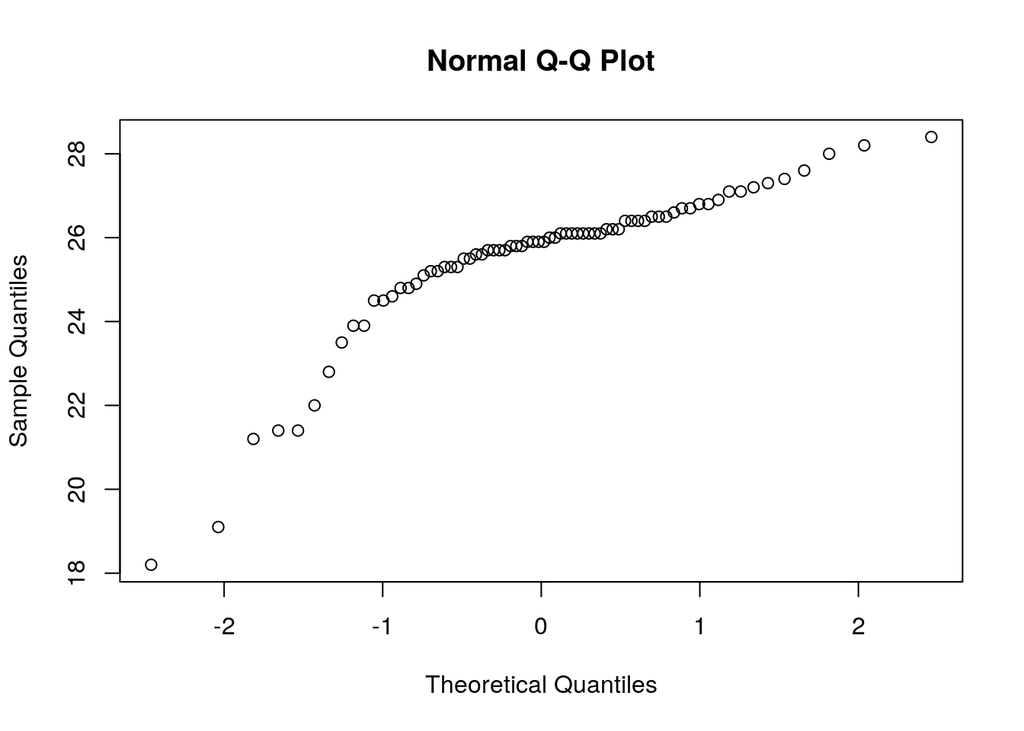

```r
qqnorm(temp$tanual)
```

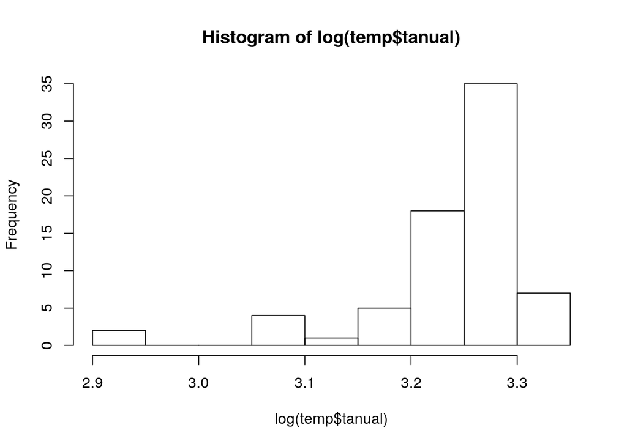

```r
hist(log(temp$tanual))
```

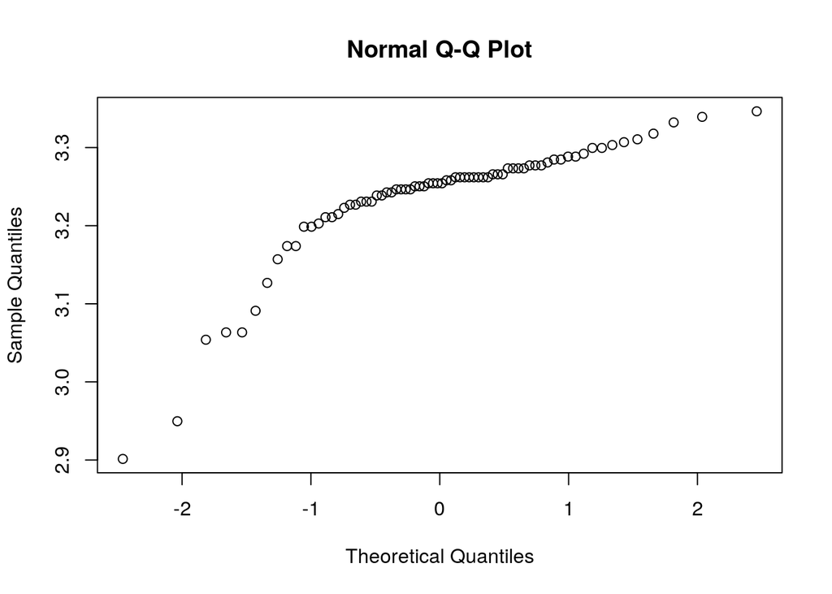

```r
qqnorm(log(temp$tanual))
```

```r
shapiro.test(temp$tanual)
```

```
##
##  Shapiro-Wilk normality test
##
## data:  temp$tanual
## W = 0.81613, p-value = 4.783e-08
```

```r
shapiro.test(log(temp$tanual))
```

```
##
##  Shapiro-Wilk normality test
##
## data:  log(temp$tanual)
## W = 0.77059, p-value = 3e-09
```

Dado que en este caso existe una fuerte desviación de una distribución normal, debemos tenerlo en cuenta al modelizar la temperatura respecto de la elevación. Al menos los residuos deberían tener distribución normal. Exploraremos el modelo oportunamente. Visualicemos los datos en un mapa

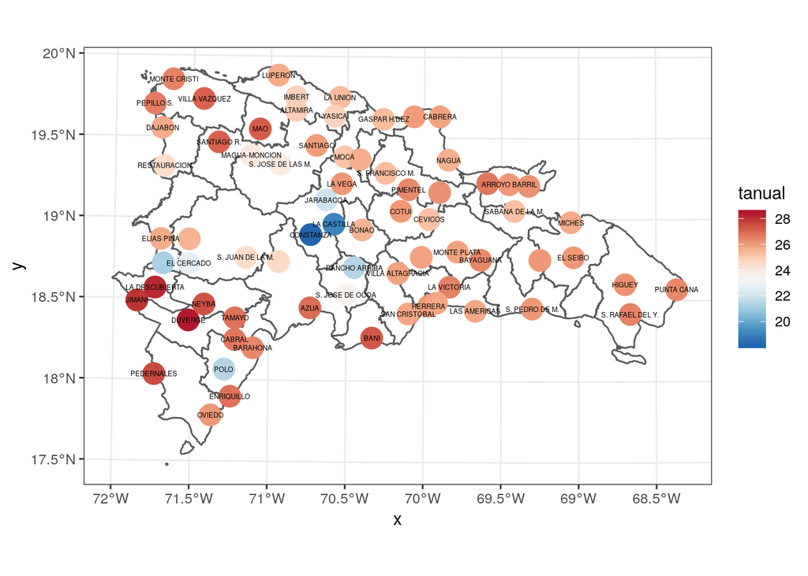

```r
library(RColorBrewer)
ggplot() +
  geom_sf(data = prov, fill = 'white') +
  geom_sf(data = temp, aes(col = tanual), size = 6) +
  scale_colour_gradientn(colours = rev(brewer.pal(9, name = 'RdBu'))) +
  geom_sf_text(data = temp, aes(label=nombre), check_overlap = T, size = 1.5) +
  theme_bw()
```

### Importar DEM

Ahora necesitamos traer el DEM, que en este caso será uno resumido a partir del SRTM-90m.

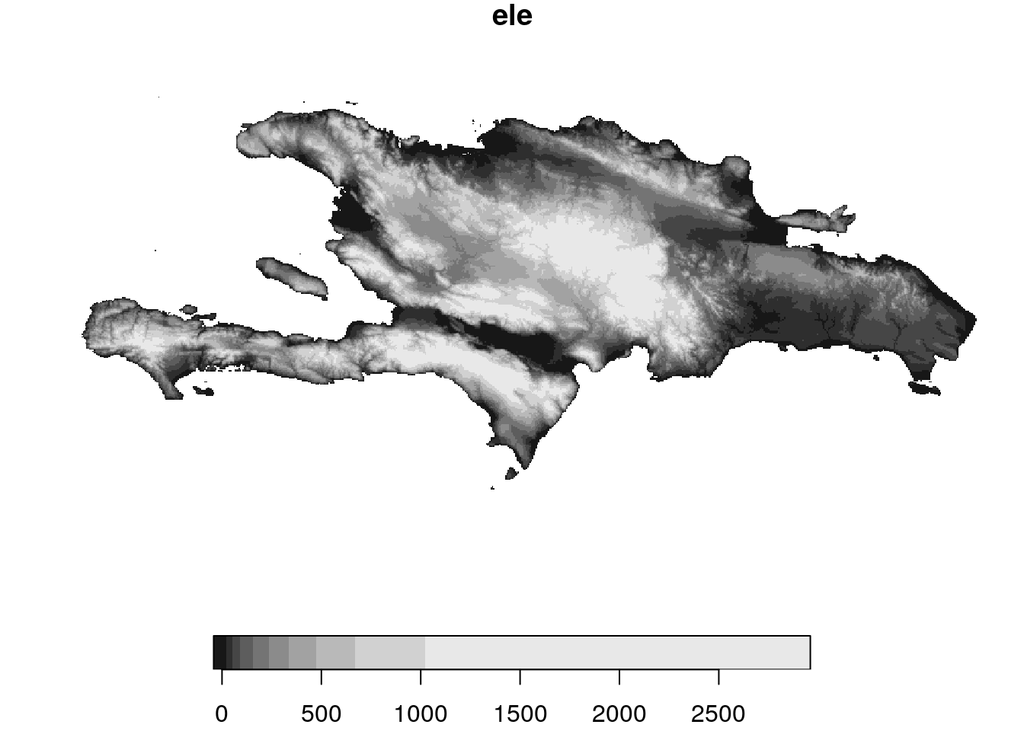

```r
dem <- read_stars('material-de-apoyo-master/data/dem_srtm_remuestreado.tif')
names(dem) <- 'ele'
plot(dem)
```

Ahora remuestreamos el DEM para que se alinee con la cuadrícula fuente, `grd`. El DEM remuestreado será la cuadrícula del covariable (variable independiente) que utilizaremos para predecir el valor de temperatura.

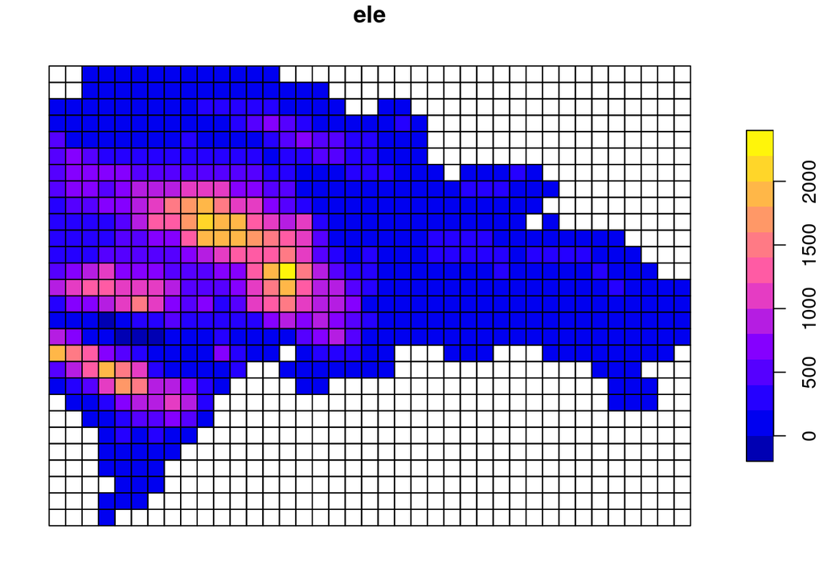

```r
grdcovars <- aggregate(dem, grd, mean, na.rm=T)
plot(grdcovars)
```

### Extraer datos de elevación y generar modelo

Necesitamos que los datos de elevación pasen al objeto `temp`, de manera que podamos probar un modelo lineal que ponga en relación a la elevación con la temperatura.

```r
temp$ele <- st_as_sf(aggregate(grdcovars, temp, mean))[[1]]
temp$ele
```

```
##  [1]   37.04137  111.19428   96.23608   89.05470   53.63334  360.12991
##  [7]   49.84021  235.65909   83.14058  155.80394 1373.07323   57.56667
## [13]   82.44868  218.63500 1042.68780  122.73364  419.19694  151.41004
## [19]   94.38337   79.46646  115.23488 1355.50136  945.64083   66.49686
## [25] 1152.72653   29.14500  165.08992   24.01264   21.70497  443.20785
## [31]   41.29578  108.17977  167.63144   25.13954   66.00372   56.24511
## [37]   -4.08697   50.94419   10.78244  140.73771   41.89802 1010.59454
## [43]   11.03355  879.47538  617.60780   84.08008   14.71723  157.90341
## [49]   99.80911   58.09217  489.49667  647.02488   61.22240  212.92748
## [55]  191.10207   29.83365   24.18545  181.29521   79.46121  241.98926
## [61]  498.26058  529.88060   11.89785   53.39107   22.52430   26.70314
## [67]  237.12488   44.10347   72.15647  271.38220         NA  690.64947
```

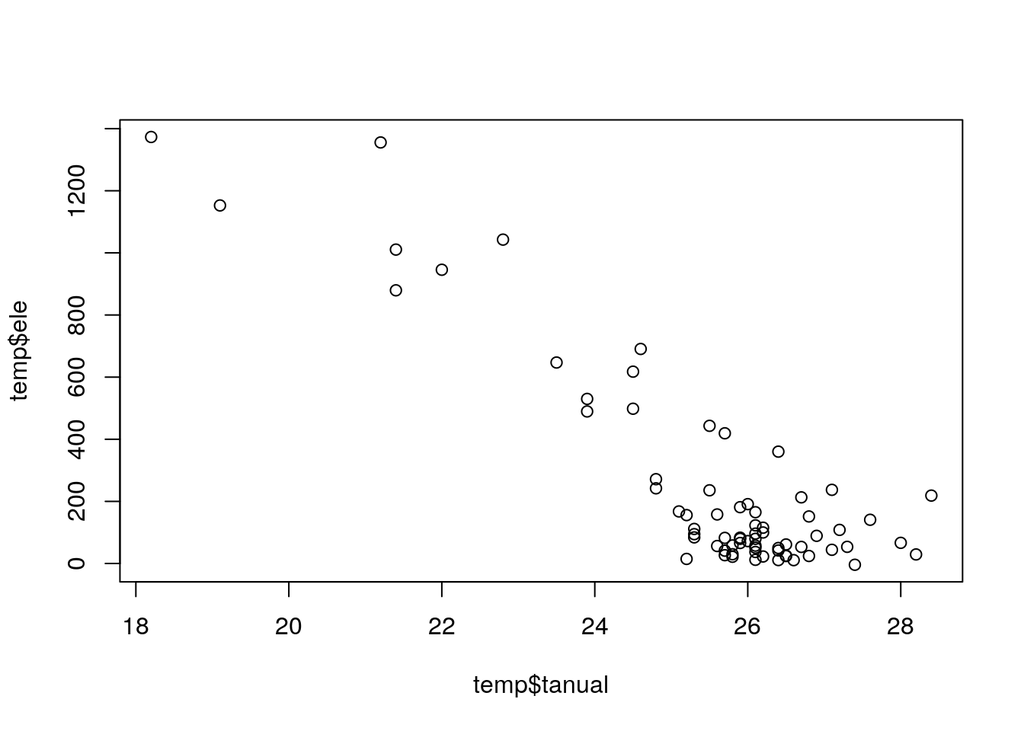

```r
temp <- temp[!is.na(temp$ele),] #Quitar observación con NA
plot(temp$tanual, temp$ele)
```

```r
temp_lm <- lm(tanual ~ ele, temp)
summary(temp_lm)
```

```
##
## Call:
## lm(formula = tanual ~ ele, data = temp)
##
## Residuals:
##     Min      1Q  Median      3Q     Max
## -1.9474 -0.5766 -0.1059  0.6037  2.7525
##
## Coefficients:
##              Estimate Std. Error t value Pr(>|t|)
## (Intercept) 26.724159   0.129657  206.11   <2e-16 ***
## ele         -0.004925   0.000314  -15.68   <2e-16 ***
## ---
## Signif. codes:  0 '***' 0.001 '**' 0.01 '*' 0.05 '.' 0.1 ' ' 1
##
## Residual standard error: 0.8768 on 69 degrees of freedom
## Multiple R-squared:  0.7809, Adjusted R-squared:  0.7777
## F-statistic: 245.9 on 1 and 69 DF,  p-value: < 2.2e-16
```

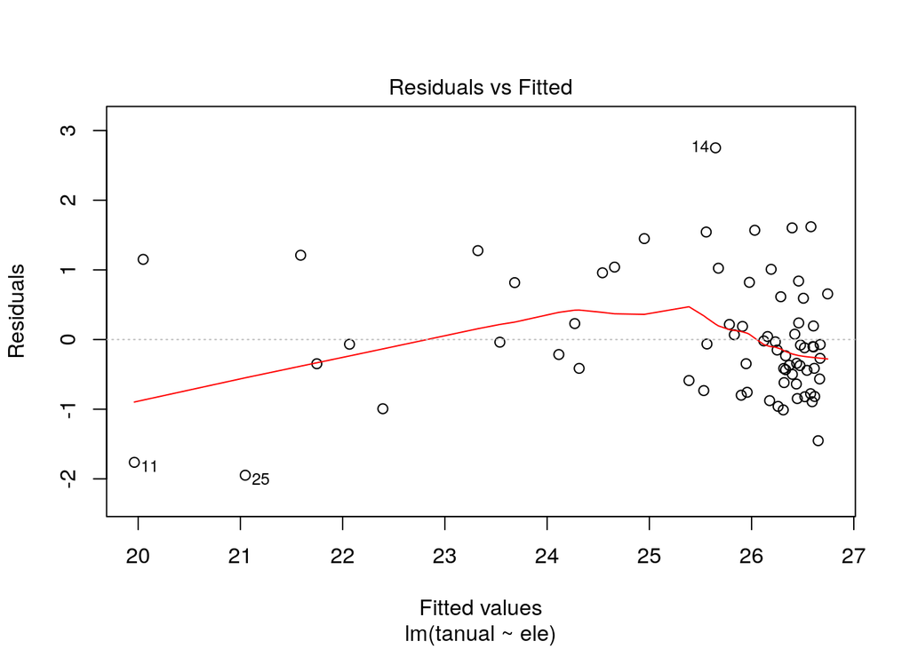

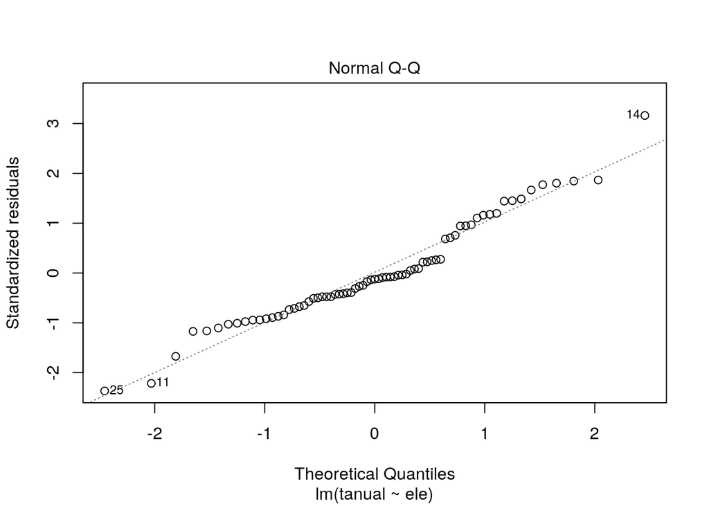

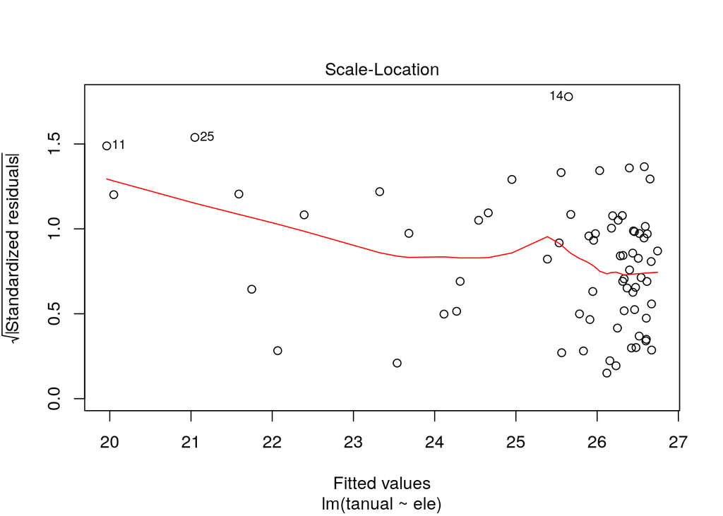

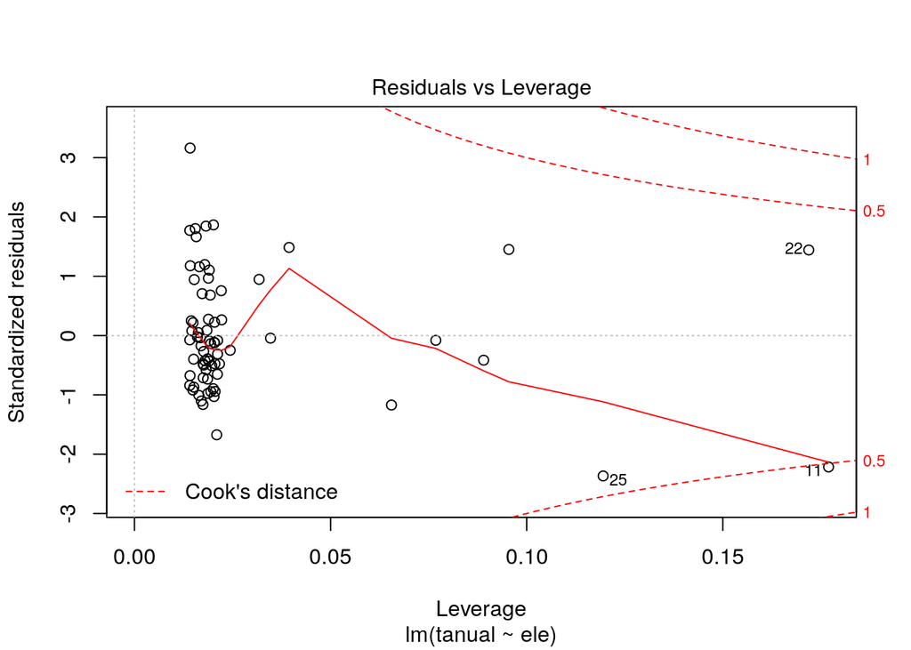

```r
plot(temp_lm)
```

El modelo sugiere que existe asociación entre temperatura y elevación, lo cual es esperable. En este caso, el gradiente resultante es de unos -0.5°C por cada 100 metros de elevación. El gradiente comúnmente es de -0.7°C/100m, pero en este caso, al utilizar un DEM resumido, el gradiente igualmente se atenúa. Generemos variograma muestral con este modelo.

### Variograma muestral

```r
vt <- variogram(tanual ~ ele, temp)
vt
```

| np | dist | gamma | dir.hor | dir.ver | id |
| --- | --- | --- | --- | --- | --- |
| 1 | 5700.529 | 0.05627847 | 0 | 0 | var1 |
| 32 | 16704.469 | 0.33635604 | 0 | 0 | var1 |
| 48 | 24262.705 | 0.54374141 | 0 | 0 | var1 |
| 71 | 33650.837 | 0.35356827 | 0 | 0 | var1 |
| 95 | 43808.242 | 0.50038750 | 0 | 0 | var1 |
| 96 | 53318.232 | 0.47861452 | 0 | 0 | var1 |
| 119 | 63032.130 | 0.55137087 | 0 | 0 | var1 |
| 114 | 72385.146 | 0.38117872 | 0 | 0 | var1 |
| 117 | 82661.116 | 0.64274923 | 0 | 0 | var1 |
| 132 | 91995.843 | 0.62593645 | 0 | 0 | var1 |

[output cut: 5 more lines]

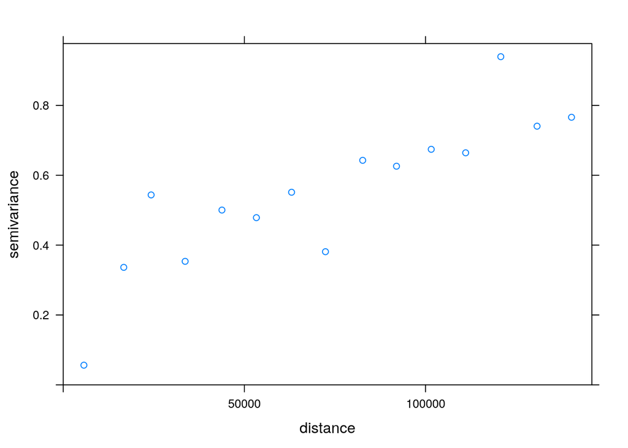

```r
plot(vt)
```

### Variograma modelo

Parecería razonable utilizar un variograma modelo exponencial con rango corto, por ejemplo, 20 o 30 km. Probemos.

```r
vt_m <- fit.variogram(vt, vgm(model = "Exp", range = 30000))
vt_m
```

| model | psill | range | kappa | ang1 | ang2 | ang3 | anis1 | anis2 |
| --- | --- | --- | --- | --- | --- | --- | --- | --- |
| Exp | 0.6121034 | 22069.9 | 0.5 | 0 | 0 | 0 | 1 | 1 |

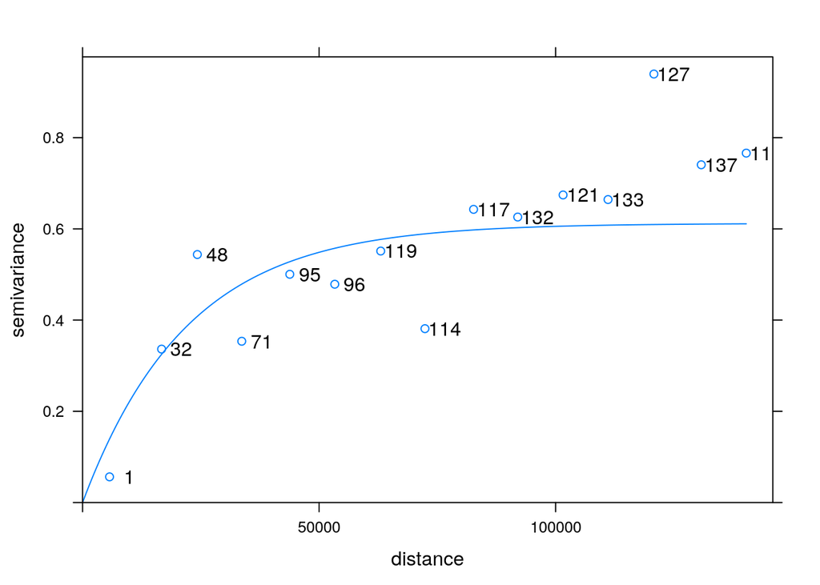

```r
plot(vt, vt_m, plot.numbers = T)
```

### Kriging universal

Finalmnente, ejecutamos el kriging.

```r
k_u <- krige(tanual ~ ele, temp, st_rasterize(st_as_sf(grdcovars)), vt_m)
```

```
## [using universal kriging]
```

Finalmente, lo representamos.

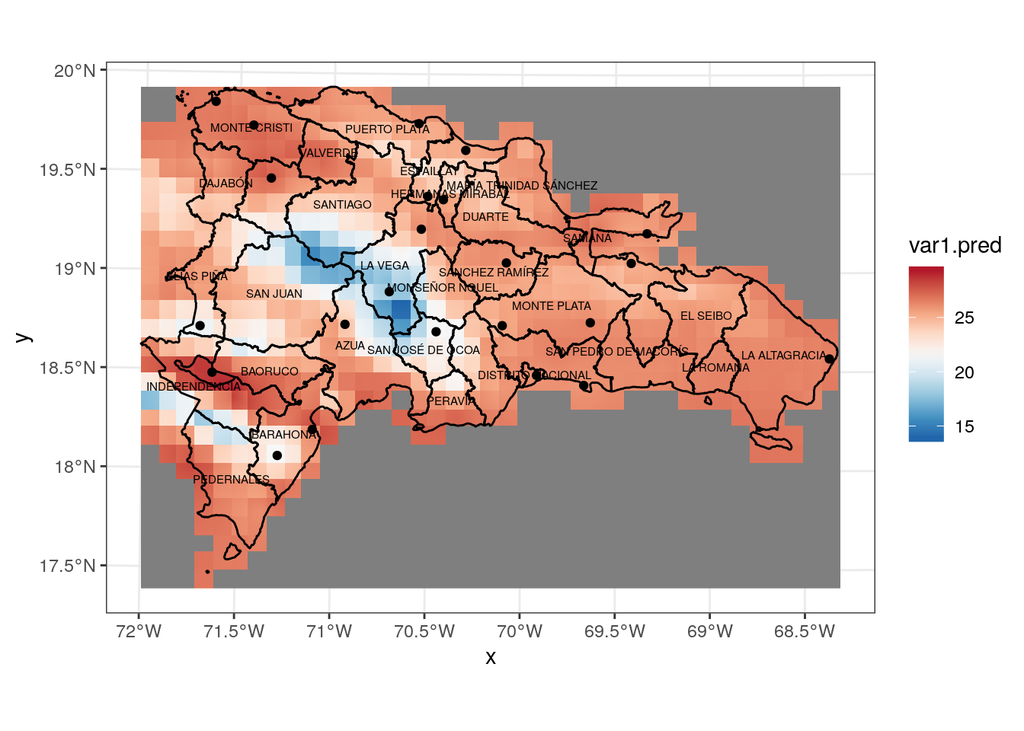

```r
ggplot() +
  geom_stars(data = k_u, aes(fill = var1.pred, x = x, y = y)) +
  scale_fill_gradientn(colours = rev(brewer.pal(9, name = 'RdBu'))) +
  geom_sf(data = st_cast(prov, "MULTILINESTRING")) +
  geom_sf(data = pre1998) +
  geom_sf_text(data = prov, aes(label=TOPONIMIA), check_overlap = T, size = 2) +
  theme_bw()
```

### Nota final

Dado que en este caso existe una fuerte desviación de los datos respecto a una distribución normal, aun usando transformación logarítmica, se recomienda aplicar otro tipo de transformación. En este caso, luce mejor emplear *Tukey Ladder of Powers* (escalera de potencias de Tukey). Usaremos la función `transformTukey` del paquete `rcompanion`, que cargaremos a continuación.

```r
library(rcompanion)
temp$tanualtrans <- transformTukey(temp$tanual, plotit = F)
hist(temp$tanualtrans)
qqnorm(temp$tanualtrans)
shapiro.test(temp$tanualtrans)
```

[output not shown]

# Resultados

Nótese que se trata de una transformación de potencia por medio del exponente `8.1`. Para hacer la transformación inversa, bastaría con aplicar `temp$tanualtrans^(1/8.1)`. Se podría ensayar con la variable transformada para generar la superficie continua.

La metodología propuesta se aplicó en Republica Dominicana Para sus diferntes provincias. logramos ejecutar un kriging ordinario para predecir el valor de la precipitación de 1998 para todo el país a partir de 21 observatorios. Notemos que se trataba de un kriging ordinario, porque a la función `krige` no le introducimos una media (argumento `beta`), e igualmente porque con la función `variogram` generamos un variograma contra un intercepto (fórmula `a1998log~1`).

realizamos un modelo lineal que pone la relación de la elevación con la temperatura.

# Discusión o Conclusiones

concluimos que la precipitacion esta directamente relacionado con la orografia del terreno y que existe asociación entre temperatura y elevación. el gradiente resultante es de unos -0.5°C por cada 100 metros de elevación. El gradiente comúnmente es de -0.7°C/100m.

utilizamos kriging universal para predecir el valor de la variable de interés en función del modelo espacial aportado por el variograma Y, al mismo tiempo, considerando covariables mediante polinomios.

# Información de soporte

Utilizamos codigos y procedimientos de la clase de datos puntuales y GeoEstadistica del profesor Jose Martinez Batlle.

# Referencias

Material de Apoyo suministrado por el profesor Jose Martinez Batlle. Capa de division de provincias de la ONE (Oficina Nacional de Estadisticas) Datos de Presipitacion Anual de La Oficina Nacional de Meterologia (ONAMET) Capa ProvCenso2010 de ONE (Oficina Nacional de Estadisticas) Datos de Temperatura(onamet_temp_anual) Registrada en Observatorios de ONAMET. utilizamos el DEM - SRTM-90m (dem_srtm_remuestreado.tif)